# Part II - Ford GoBike System

## by David Okpare

## Investigation Overview

> The focus will be on the differences between rides taking by Subscribers and rides taken by Customers. The distances users cover, the schedule (timings) they adopt, and whether or not they share bikes.

## Dataset Overview

> Ford GoBike System Dataset includes information about individual rides made in a bike-sharing system covering the greater San Francisco Bay area. The rides details are collected for the month of February 2019 across 329 stations all day.

## Bike Sharing is only for Subscribers.

> The distribution of rides shared per user type shows there were no rides shared among Customers. Observation shows that the bike sharing option was only completed by Subcribers.

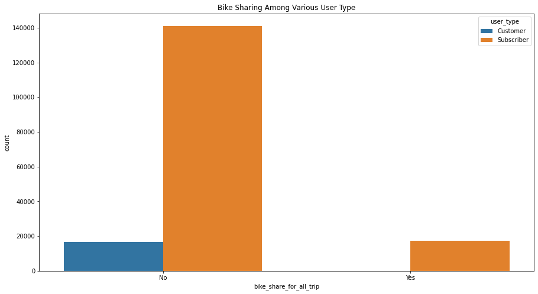

## Subscribers take more and longer rides

> It's been observed that Subscribers tend to explore longer distances compared to Customers. Subscribers explored more than 15km and upto 60 km in the recorded rides. While Customers tend to settle for shorter distance, as the maximum distance explored was slightly above 12km.

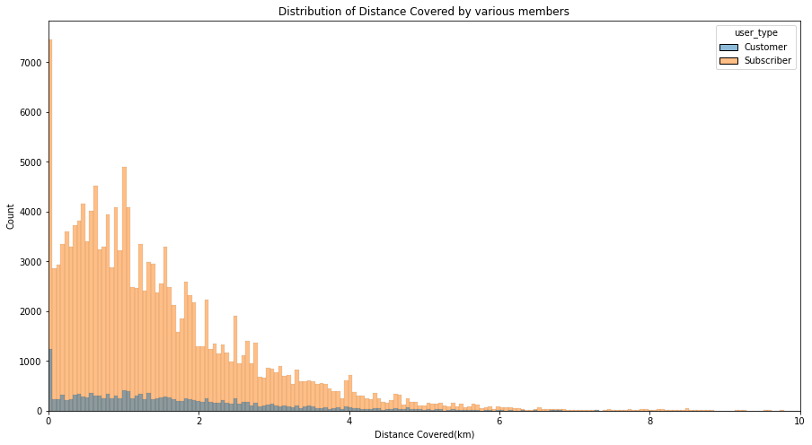

## When do clients take rides?

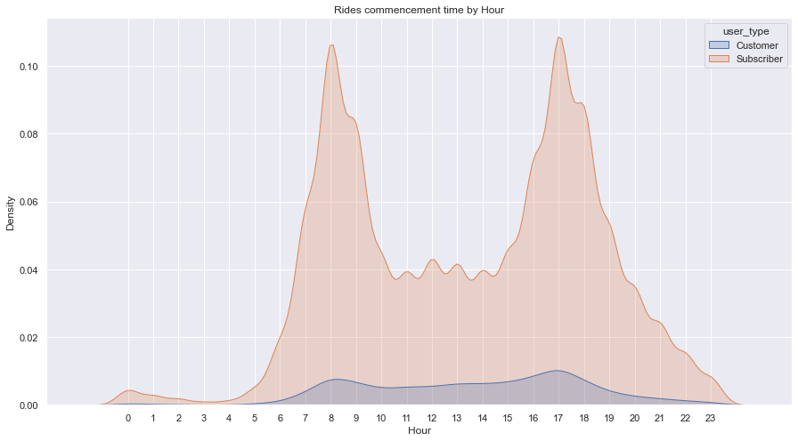

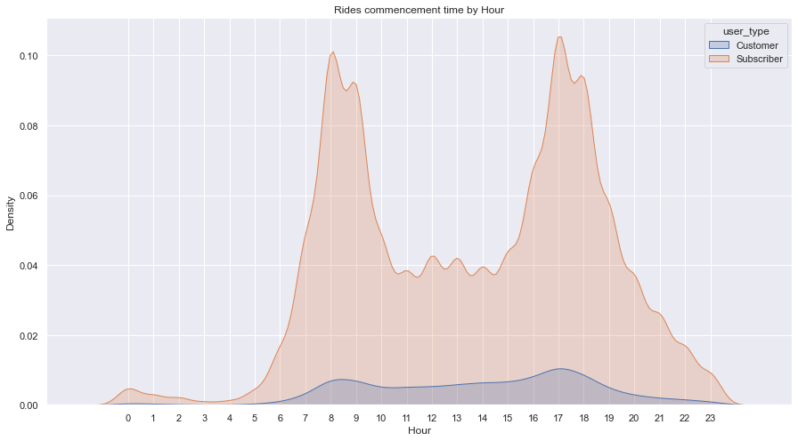

## Conclusions

There are many insights discovered from the FordBike 2019 dataset. Drawing on the observations found in the charts, these are some focal points.

> Subscribers mostly take rides between 7am to 9am and 4pm to 6pm while Customers have an almost steady increase in rides between 7am and 6pm.